# Modelos de Intervención y Detección de Valores Atípicos

Fernando Salcedo Mejía Eco, Ms

2026-02-01

# Introducción

En esta unidad, se exploran los modelos de intervención y cómo detectar y manejar valores atípicos en las series temporales. Se analiza la importancia de detectar estos valores para mejorar la calidad de los modelos y las predicciones.

- Modelos de intervención: definición y aplicaciones
- Tipos de valores atípicos: aditivos, innovadores y multiplicativos
- Técnicas para la detección y corrección de valores atípicos
- Ejemplos de análisis de intervención y manejo de valores atípico

# Modelos de intervención: definición y aplicaciones

## Modelos de intervención

Las series temporales interrumpidas permiten evaluar el impacto de las intervenciones en ámbitos diversos como programas sociales, epidemiología, campañas de marketing, política de tasas e impuestos, regulaciones, etc. Existe básicamente dos patrones del cambio :

- **Cambio de nivel :** cambio brusco de la serie posterior de la intervención.
- **Cambio de tendencia :** cambio gradual en el crecimiento de la serie despúes de la intervención.

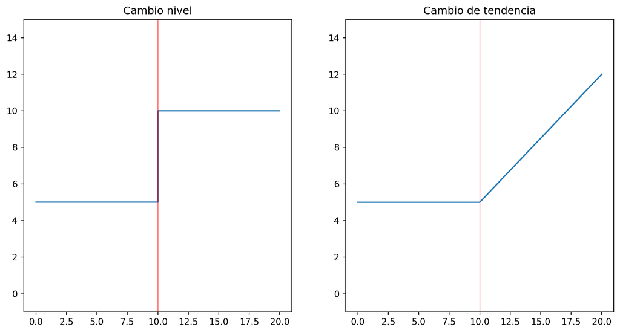

```python
import numpy as np
import matplotlib.pyplot as plt

x1_base = np.array([0, 10, 10, 20])
y1_base = np.array([5, 5, 10, 10])

x2_base = np.array([0, 10, 20])
y2_base = np.array([5, 5, 12])

fig, axs = plt.subplots(1, 2, figsize=(12, 6))
axs[0].plot(x1_base, y1_base)
axs[0].set_xlim(-1, 21)
axs[0].set_ylim(-1, 15)
axs[0].axvline(x=10, color='red', linestyle='-', linewidth=0.8, alpha=0.7)
axs[0].set_title("Cambio nivel")

axs[1].plot(x2_base, y2_base)
axs[1].axvline(x=10, color='red', linestyle='-', linewidth=0.8, alpha=0.7)
axs[1].set_xlim(-1, 21)
axs[1].set_ylim(-1, 15)
axs[1].set_title("Cambio de tendencia")

plt.show()
```

## Serie temporal interrumpida (ITR)

- Está formado por dos períodos de múltiples observaciones registradas, antes y después de la intervención. Se trata de comprobar, si a partir del punto de intervención se ha **producido un cambio en el patrón de los datos.**
- Por lo general, se espera encontrar que la pendiente o el nivel de la serie sea contingente a la aplicación de la intervención. Este diseño recibe el nombre de serie temporal interrumpida, porque la inferencia causal se basa en detectar o descubrir un cambio abrupto en los valores de la variable dependiente.

$$Y_t = \beta_0 + \beta_1 t + \beta_2 D_t + \beta_3 \left[t - T_I \right] D_t + \eta_t$$

Donde :

- ${Y}_{t}$ es la serie de tiempo
- $D_t$ es una variable indicadora que representa el intervalo posterior a la interrupción: codificada como 0 en el período anterior a la interrupción y como 1 en el período posterior a la interrupción.
- $T_I$ es el momento en el timpo de la intervención.
- $\left[t - T_I \right] D_t$ representa el cambio de pendiente, igual a cero hasta el momento de la intervención y despúes incrementa $1, 2, \dots, N$.
- Los parámetros del modelo representan la intersección de referencia ($\beta_0$); la pendiente previa a la interrupción ($\beta_1$); el cambio de nivel en la interrupción ($\beta_2$), y el cambio de pendiente ($\beta_3$).
- $\eta_t$ sigue un proceso de autocorrelación.

## Serie temporal interrumpida

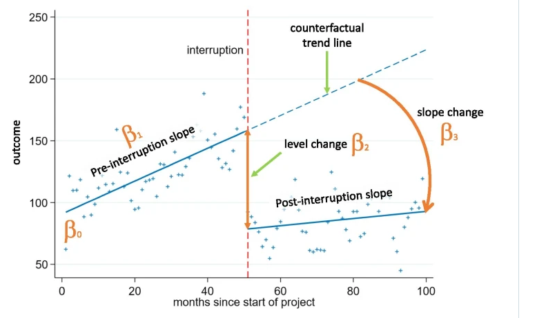

Tomado de Turner (2021).

## Modelos usandos en ITR.

- Siendo una serie de tiempo, sabes que $\eta_t$ sigue un proceso de autocorrelación. Básicamente se usa dos métodos para estimar el modelo :
- Modelo ARIMA(p, d, q) donde sus residuos $\varepsilon_t \sim WN$
- Mínimos Cuadrados Ordinarios (OLS) con errores estándar de Newey-West

## Modelo ITR-ARIMA

- Usamos el modelo ARIMA(p, d, q) para modelar la autocorrelación de los residuales del modelo ITR $\eta_t$

$$Y_t = \beta_0 + \beta_1 t + \beta_2 D_t + \beta_3 \left[t - T_I \right] D_t + \eta_t \\
(1-\phi_1B)(1-B)\eta_t = (1+\theta_1B)\varepsilon_t \\
\varepsilon_t \sim WN$$

## Modelo OLS-Newey-West ITR

- El estimador de Newey-West (también conocido como HAC: *Heteroskedasticity and Autocorrelation Consistent*) recalcula la matriz de varianza-covarianza epara que los errores estándar sean robustos ante la presencia de autocorrelación y heterocedasticidad sin cambiar los coeficientes $\beta$ calculados por OLS.
- Matriz de Varianza-Covarianza General
  $$\hat{\Sigma}_{HAC} = (X^T X)^{-1} \hat{\Omega} (X^T X)^{-1}$$
- Estimador Omega ($\hat{\Omega}$)
  $$\hat{\Omega} = \sum_{t=1}^{T} e_t^2 x_t x_t^T + \sum_{j=1}^{L} w_j \sum_{t=j+1}^{T} e_t e_{t-j} (x_t x_{t-j}^T + x_{t-j} x_t^T)$$

Esta parte se le conoce como el estimador de **heterocedasticidad de White** ($\sum_{t=1}^{T} e_t^2 x_t x_t^T$)

- Pesos de Bartlett : Esto significa que los rezagos más cercanos tienen más peso que los rezagos más lejanos en el cálculo del error.

$$w_j = 1 - \frac{j}{L + 1}$$

- Heterocedasticidad: Ajusta si la varianza de los errores no es constante
- Autocorrelación: Ajusta si el error de hoy depende del error de ayer. Requiere definir un lag (rezago) máximo hasta el cual se sospecha que existe correlación.

## Sesgos de los estimadores ITR :

**Amenazas a la validez interna :**

- La principal amenaza a la validez interna o validez de inferencia es, el factor **historia**. La historia se refiere a hechos o **acontecimientos externos** distintos al tratamiento que actúan en el punto de intervención y que pueden afectar a la conducta en curso.
- Otra amenaza son :
  - **Selección**. Cambios en la definición de la serie despúes de la intervención.
  - **Instrumentación**. Un cambio en los procedimientos administrativos puede modificar la forma como los registros son guardados.

## Serie temporal interrumpida (ITR) con grupo de control no equivalente.

- El diseño de serie temporal interrumpida con grupo control no equivalente es una extensión del diseño de serie temporal simple y permite investigar hipótesis más precisas al comparar una serie temporal experimental con otra de control. En consecuencia, se controlan mejor las posibles hipótesis rivales.
- **Supuestos :**
- Suponemos que los grupos de tratamiento y control evolucionan de forma similar a lo largo del tiempo.
- Podemos estimar fácilmente la pendiente del grupo de control desde antes hasta después del tratamiento.
- Podemos realizar un **análisis contrafactual** y preguntarnos: ¿Cuál sería el resultado posterior al tratamiento del grupo de tratamiento si no lo hubieran recibido?.

## Estimador Diferencias en Diferencias (o Diff-in-Diff / DiD)

- El modelo de DiD es una técnica econométrica diseñada para estimar efectos causales comparando el cambio en los resultados a lo largo del tiempo entre un grupo que recibe un tratamiento y un grupo de control.
- La idea central es que, en ausencia del tratamiento, la diferencia entre el grupo de tratamiento y el de control se habría mantenido constante. Esto se conoce como el supuesto de tendencias paralelas.
- Para calcularlo estadísticamente (y poder incluir variables de control), se utiliza una regresión lineal con una interacción:

$$Y_{t} = \beta_0 + \beta_1 \text{Treatment}_t + \beta_2 \text{Post}_t + \beta_3 (\text{Treatment}_t \cdot \text{Post}_t) + \varepsilon_{t}$$

Donde :

- $\beta_0$: Intercepto (valor base del grupo de control en el periodo pre-intervención).
- $\text{Treatment}_i$: Variable binaria (1 si pertenece al grupo tratado, 0 si es control).
- $\text{Post}_t$: Variable binaria (1 si es el periodo después de la intervención, 0 si es antes).
- $\beta_3$: El estimador de **Diferencia en Diferencias** (el efecto causal bajo supuestos!).

## Estimador Diferencias en Diferencias (o Diff-in-Diff / DiD)

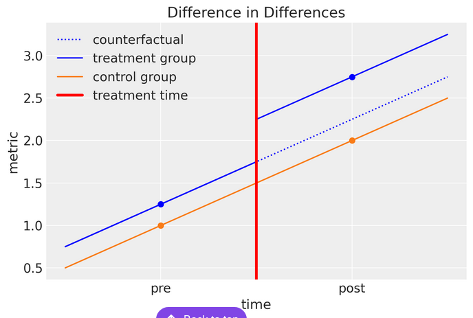

## Estimadores avanzados : Modelos de Espacio de Estados Bayesianos.

- El modelo **construye un contrafactual**; es decir, predice qué habría pasado con la serie temporal si la intervención nunca hubiera ocurrido. Para ello usa un enfoque bayesiano usando **modelos de espacio de estados** y cadenas de Markov basadas en probabilidad para la inferencia a posteriori de la intervención.
- Por ejemplo, **¿cuántos clics diarios adicionales generó una campaña publicitaria?** Responder a una pregunta como esta puede resultar difícil cuando no se dispone de un experimento aleatorio.

**Para ello necesita :**

**Grupo de control sintético:** Utiliza otras series temporales que no fueron afectadas por la intervención (predictores) para ayudar a predecir la evolución de la variable objetivo.

**Comparación:** El efecto causal es la diferencia acumulada entre lo que realmente se observó y lo que el modelo predijo (el contrafactual).

**Efecto puntual:**
$$\tau_t = y_t - \hat{y}_t(0)$$

**Efecto acumulado:**

$$\Delta = \sum_{t=t_{int}}^{T} (y_t - \hat{y}_t(0))$$

Donde : - $\hat{y}_t(0)$: Es la predicción contrafactual (lo que el modelo estima que habría pasado sin intervención).

## Salida del modelo CausalImpact

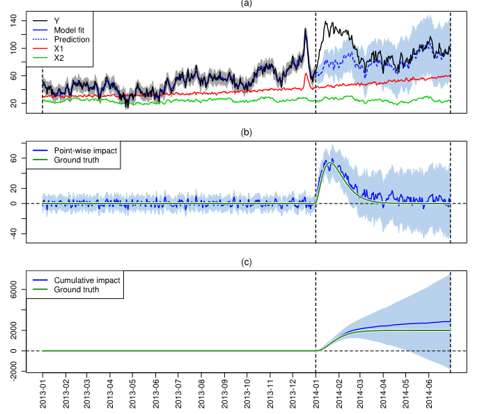

## Ejemplos resueltos

- Ver cuadernos de jupyther en Python/R

## Referencias

- Hyndman, R. J., & Athanasopoulos, G. (2021). *Forecasting: Principles and Practice*. 3rd ed. OTexts. Available at: https://otexts.com/fpp3/
- Turner, S.L., Karahalios, A., Forbes, A.B. et al. Comparison of six statistical methods for interrupted time series studies: empirical evaluation of 190 published series. BMC Med Res Methodol 21, 134 (2021). https://doi.org/10.1186/s12874-021-01306-w
- Scott Cunningham. Causal inference: The Mixtape. Yale University Press, 2021.
- Brodersen KH, Gallusser F, Koehler J, Remy N, Scott SL. Inferring causal impact using Bayesian structural time-series models. Annals of Applied Statistics, 2015, Vol. 9, No. 1, 247-274. http://research.google.com/pubs/pub41854.html